# Mapa de población en situación de discapacidad

Censo de Población y Vivienda 2020

Diana Villasana Ocampo

## Censo de Población y Vivienda 2020

En el Censo de Población y Vivienda, la población con discapacidad se estructura a través de una serie de preguntas y variables diseñadas para identificar a las personas con diferentes tipos y grados de discapacidad. El objetivo principal es obtener datos precisos que permitan conocer la magnitud, distribución y características de esta población para la formulación de políticas públicas y la asignación de recursos.

Las principales preguntas y variables que se consideran en el Censo para identificar a la población con discapacidad son:

**Dificultad para realizar actividades básicas:** Se pregunta sobre el grado de dificultad que tiene la persona para realizar actividades consideradas fundamentales en la vida diaria. Estas actividades incluyen:

- **Ver:** Aunque use lentes.
- **Oír:** Aunque use aparato auditivo.
- **Caminar, subir o bajar:** Usando sus piernas.
- **Recordar o concentrarse:** Incluye dificultades para aprender cosas nuevas o mantener la atención.
- **Bañarse, vestirse o comer:** Actividades de cuidado personal.
- **Hablar o comunicarse:** Entender o ser entendido por otras personas.
- **Mover o usar brazos o manos.**

**Grado de dificultad:** Para cada una de las actividades mencionadas, se ofrecen diferentes opciones de respuesta que indican el nivel de dificultad:

- No tiene dificultad.
- Poca dificultad.
- Mucha dificultad.
- No puede hacerlo.

**Problema o condición mental:** Se incluye una pregunta directa sobre si la persona tiene algún problema o condición mental, como autismo, síndrome de Down, esquizofrenia, etc.

**Causa de la limitación o discapacidad:** En algunos cuestionarios ampliados del Censo, se pregunta sobre la causa principal de la limitación, discapacidad o problema mental. Esto ayuda a entender el origen de las discapacidades.

[figure not shown]

**Elaboración propia**

## Marco Geoestadístico Nacional (`MGN`)

El **Marco Geoestadístico Nacional (MGN)** del Instituto Nacional de Estadística y Geografía (INEGI) es un **sistema único y de carácter nacional** diseñado para **referenciar geográficamente la información estadística** que se genera a través de los censos y encuestas que realiza el Instituto, así como otra información estadística de interés nacional.

- **Área Geoestadística Estatal (AGEE)**
- **Área Geoestadística Municipal (AGEM)**
- **Área Geoestadística Básica (AGEB) urbana y rural**
- **Localidad geoestadística urbana y rural**
- **Manzana geoestadística**
- **Vialidad**
- **Frente de manzana**

## Shapefiles

A continuación, se leen y se transforman los shapefiles de las divisiones geográficas de los estados de México correspondientes a las siguientes desagregaciones geográficas.

Utilizando la paquetería `rgdal`, se definen los siguientes parámetros:

- `readOGR`: Esta función se usa para leer shapefiles.
- `dsn`: Especifica la ruta al directorio que contiene el shapefile.
- `layer`: Especifica el nombre de la capa dentro del shapefile.
- `encoding`: Especifica la codificación de los caracteres, en este caso, UTF-8.
- `use_iconv`: Se usa para convertir la codificación si es necesario.

Una vez cargados los sahpefiles, se transforman los sistemas de coordenadas:

- `spTransform`: Esta función se usa para transformar las coordenadas del shapefile a un nuevo sistema de referencia.
- `CRSobj`: Especifica el sistema de referencia de coordenadas de destino. En este caso, se usa el sistema de coordenadas geográficas (latitud y longitud) basado en el elipsoide y `datum WGS84`.

Estos pasos son cruciales para asegurar que los datos geoespaciales sean consistentes y compatibles para su uso en análisis geográficos y visualización, por ejemplo, en aplicaciones de Leaflet o cualquier otro software de mapeo.

**Shapefile estados 2020**

```r
shape_estados <- readOGR(dsn = "D:/MGN/MGN 2020/MGN 2020/conjunto_de_datos",
                          layer = "00ent",
                           encoding = "UTF-8",
                            use_iconv = TRUE)

shape_estados <- spTransform(shape_estados, CRSobj = CRS('+proj=longlat +ellps=WGS84 +datum=WGS84 +no_defs'))
```

**Shapefile municipios 2020**

```r
shape_municipios <- readOGR(dsn = "D:/MGN/MGN 2020/MGN 2020/conjunto_de_datos",
                             layer = "00mun",
                              encoding = "UTF-8",
                               use_iconv = TRUE)

shape_municipios <- shape_municipios %>%
                     sp::spChFIDs(., str_pad(shape_municipios@data$CVEGEO, 5, "left", pad = "0"))

shape_municipios <- spTransform(shape_municipios, CRSobj = CRS('+proj=longlat +ellps=WGS84 +datum=WGS84 +no_defs'))
```

Se cargan las bases de datos de discapacidad, obtenido del los tabulados básicos del Censo de Población y Vivienda 2020 [(Enlace)](https://www.inegi.org.mx/programas/ccpv/2020/#tabulados)

```r
mydata <- read.xlsx("Bases/Población con discapacidad por municipios.xlsx",
                    sheet = "Municipios",
                    colNames = TRUE,
                    startRow = 4)
```

Población total Por: Entidad y municipio Según: Limitación o discapacidad y número

Censo de Población y Vivienda 2020

| CVE_MUN | Municipio | Total | Población.con.discapacidad | Con.limitación,.discapacidad.o.algún.problema.o.condición.mental | Con.limitación | Sólo.con.limitación | Con.limitación.y.algún.problema.o.condición.mental | Con.discapacidad | Sólo.con.discapacidad | Con.discapacidad.y.algún.problema.o.condición.mental | Sólo.con.algún.problema.o.condición.mental | Sin.limitación,.discapacidad.o.algún.problema.o.condición.mental | No.especificado |
| --- | --- | --- | --- | --- | --- | --- | --- | --- | --- | --- | --- | --- | --- |
| 00 | Nacional | 126 014 024 | 7 168 178 | 20 838 108 | 13 934 448 | 13 669 930 | 264 518 | 6 179 890 | 5 577 595 | 602 295 | 723 770 | 104 815 785 | 360 131 |
| 01001 | Aguascalientes | 948 990 | 56 153 | 170 131 | 116 705 | 113 978 | 2 727 | 47 525 | 42 208 | 5 317 | 5 901 | 777 394 | 1 465 |
| 01002 | Asientos | 51 536 | 3 343 | 7 809 | 4 551 | 4 466 | 85 | 2 886 | 2 651 | 235 | 372 | 43 707 | 20 |
| 01003 | Calvillo | 58 250 | 4 791 | 11 378 | 6 760 | 6 587 | 173 | 4 088 | 3 600 | 488 | 530 | 46 834 | 38 |
| 01004 | Cosío | 17 000 | 934 | 2 834 | 1 933 | 1 900 | 33 | 805 | 728 | 77 | 96 | 14 166 | NA |
| 01010 | El Llano | 20 853 | 1 278 | 3 852 | 2 610 | 2 574 | 36 | 1 141 | 1 053 | 88 | 101 | 16 986 | 15 |
| 01005 | Jesús María | 129 929 | 6 111 | 17 724 | 11 904 | 11 613 | 291 | 5 036 | 4 469 | 567 | 784 | 112 021 | 184 |
| 01006 | Pabellón de Arteaga | 47 646 | 2 948 | 8 682 | 5 833 | 5 734 | 99 | 2 624 | 2 391 | 233 | 225 | 38 914 | 50 |
| 01007 | Rincón de Romos | 57 369 | 3 715 | 10 282 | 6 689 | 6 567 | 122 | 3 323 | 3 023 | 300 | 270 | 46 923 | 164 |
| 01011 | San Francisco de los Romo | 61 997 | 2 676 | 7 851 | 5 295 | 5 175 | 120 | 2 234 | 2 010 | 224 | 322 | 54 018 | 128 |
| 01008 | San José de Gracia | 9 552 | 630 | 1 749 | 1 135 | 1 119 | 16 | 569 | 523 | 46 | 45 | 7 803 | NA |
| 01009 | Tepezalá | 22 485 | 1 236 | 3 259 | 2 067 | 2 023 | 44 | 1 063 | 990 | 73 | 129 | 19 172 | 54 |
| 02001 | Ensenada | 443 807 | 24 482 | 69 832 | 46 474 | 45 350 | 1 124 | 20 367 | 18 289 | 2 078 | 2 991 | 373 113 | 862 |
| 02002 | Mexicali | 1 049 792 | 55 080 | 156 147 | 103 539 | 101 067 | 2 472 | 44 519 | 39 964 | 4 555 | 8 089 | 892 043 | 1 602 |
| 02005 | Playas de Rosarito | 126 890 | 6 536 | 18 452 | 12 170 | 11 916 | 254 | 5 391 | 4 821 | 570 | 891 | 107 464 | 974 |
| 02006 | San Quintín | 117 568 | 7 131 | 19 065 | 12 139 | 11 934 | 205 | 6 329 | 5 876 | 453 | 597 | 98 341 | 162 |
| 02003 | Tecate | 108 440 | 5 313 | 15 656 | 10 625 | 10 343 | 282 | 4 104 | 3 631 | 473 | 927 | 92 428 | 356 |
| 02004 | Tijuana | 1 922 523 | 90 065 | 262 207 | 176 322 | 172 142 | 4 180 | 71 235 | 63 507 | 7 728 | 14 650 | 1 650 276 | 10 040 |
| 03001 | Comondú | 73 021 | 5 098 | 14 114 | 9 169 | 9 016 | 153 | 4 530 | 4 125 | 405 | 415 | 58 836 | 71 |
| 03003 | La Paz | 292 241 | 18 110 | 55 259 | 38 052 | 37 149 | 903 | 15 395 | 13 730 | 1 665 | 1 812 | 235 733 | 1 249 |

Fuente: INEGI. Censo de Población y Vivienda 2020. Tabulados del Cuestionario Básico

### SpatialPolygons ➡️ data.frame

Este código realiza las siguientes acciones:

- `spdplyr:::left_join.Spatial()`, Realiza un merge entre shape_municipios_ y el dataframe modificado, usando `CVEGEO` como clave.

El resultado es un nuevo objeto Spatial (layer_municipios) que combina la geometría de shape_municipios con la información adicional de `mydata`.

```r
layer_municipios <- spdplyr:::left_join.Spatial(shape_municipios,
                                                 mydata %>%
                                                  mutate(CVEGEO = str_pad(.$CVE_MUN, width = 5, side = "left", pad = "0")),
                                                   by = c("CVEGEO"))
```

## Mapa a nivel municipal

Paso a paso:

1. **`mutate(Pob.Discapacidad = ...`**: Crea una nueva variable que representa el porcentaje de población con discapacidad respecto al total.
2. **`mutate(decil_discapacidad = cut(...`**: Divide esa variable en 20 grupos (vigintiles) según su distribución.

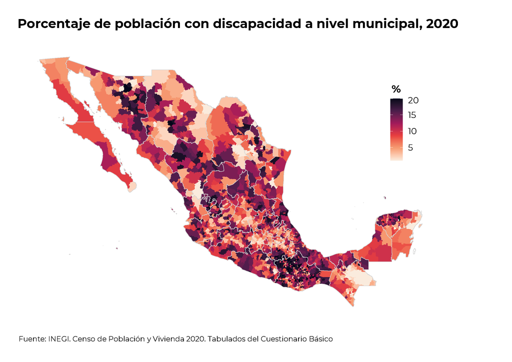

```r
# Paquete
require(ggspatial)

paleta <- colorRampPalette(pals::kovesi.linear_bmy_10_95_c78(10))(5)

layer_municipios <- layer_municipios %>%
                      mutate(Pob.Discapacidad = .$`Población.con.discapacidad`/.$Total * 100) %>%
                       mutate(decil_discapacidad = cut(Pob.Discapacidad,
                                                       breaks = quantile(Pob.Discapacidad, probs = seq(0, 1, 0.05), na.rm = TRUE),
                                                       include.lowest = TRUE,
                                                       labels = FALSE))

p <- ggplot() +
      layer_spatial(layer_municipios, aes(fill = decil_discapacidad), color = "transparent") +
       layer_spatial(layer_estados,
                     color = "lightgrey",
                     fill = "transparent",
                     size = 0.6) +
        theme_transparent() +
         theme(plot.title = element_text(size = 21, hjust = 0.15, family = "Montserrat", face = "bold"),
               plot.subtitle = element_text(size = 18, hjust = 0, family = "Montserrat Medium"),
               plot.caption = element_text(size = 11, hjust = 0.2, vjust = 1, family = "Montserrat"),
               axis.text = element_blank(),
               axis.title = element_blank(),
               axis.ticks = element_blank(),
               legend.key.size = unit(0.5, "cm"),
               legend.text = element_text(size = 10, family = "Montserrat"),
               legend.title = element_text(size = 12, hjust = 0.5, family = "Montserrat", face = "bold"),
               legend.position = c(0.8, 0.7)) +
          scale_fill_viridis_c(option = "F", direction = -1) +
           # scale_color_viridis_d(option = "B") +
     labs(title = "Porcentaje de población con discapacidad a nivel municipal, 2020",
           fill = stringr::str_wrap("%", 10),
            caption = expression(paste("Fuente: INEGI. Censo de Población y Vivienda 2020. Tabulados del Cuestionario Básico")))

#path = "Output/Mapa de porcentaje de poblacion con discapacidad_Municipal.pdf"
#ggexport(p, width = 8, height = 5, res = 400, filename = path)

p
```

## Referencias

This work by **Diana Villasana Ocampo** is licensed under a [Creative Commons Attribution 4.0 International License](http://creativecommons.org/licenses/by/4.0/).